# BioMedical Data Manifest

## Aggregator

#### GDC Project ID: BEATAML1.0-COHORT

GDC Summary page not available

*General Information*

LINKS

DATA MANIFEST AUTHORS

- **Data Links:**
  - **Raw:**
    - [dbGaP](https://www.ncbi.nlm.nih.gov/projects/gap/cgi-bin/study.cgi?study_id=phs001657.v3.p1)
    - [Genomic Data Commons](https://gdc.cancer.gov/access-data/obtaining-access-controlled-data)
  - **Processed:**
    - [Genomic Data Commons](https://portal.gdc.cancer.gov/projects/BEATAML1.0-COHORT)
- **Documentation (If different):**
  - For GDC specific workflows see this [link](https://docs.gdc.cancer.gov/Data/Introduction/), otherwise accompanying dataset manuscripts
- Data Manifest aggregated from GDC

VERSION INFORMATION

KEYWORDS

- Current Version: Data Release 42.0
- DOI: N/A
- Release Date: January 30, 2025
- Last Updated: N/A
- Hematopoietic and reticuloendothelial systems
- Plasma Cell Tumors
- Myelodysplastic Syndromes
- Chronic Myeloproliferative Disorders
- Myeloid Leukemias
- Leukemias, NOS

EXTENSION MECHANISMS

- Contact Dataset Owners/Publishers for ways to contribute

OWNER/PUBLISHER

CONTACT DETAILS

- N/A

**Dataset Contacts:**

- Jeffrey W. Tyner, PhD. Oregon Health and Science University, Knight Cancer Institute, Portland, OR, USA.

Uses of Data

DATASET ORIGINAL USE

CONCERNS AND LIMITATIONS

- N/A
- **Disease-Specific (Leukemia):** Use of the data must be related to Leukemia.

CONFOUNDING FACTORS

DATASET KNOWN PUBLICATIONS AND BENCHMARKS

- N/A
- N/A

CITATION GUIDELINES

**When using this dataset please cite:**

- **Use of data from dbGaP:** Please cite/reference the use of dbGaP data by including the dbGaP accession phs001657
- **Acknowledgement Statement:** We thank all of our patients at all sites for donating precious time and tissue. DNA and RNA quality assessments, library creation, and short read sequencing assays were performed by the OHSU Massively Parallel Sequencing Shared Resource. Sheenu Sheela, Catherine Lai, Katherine Lindblad and Kary Oetjen assisted in study coordination at NIH. Barry Sawicki and Christina Cline assisted in study coordination at the University of Florida. S. Ravencroft assisted with patient sample shipping and data entry and K. Schorno provided project management and support of activities at the University of Kansas Cancer Center. Jack Taw assisted with patient sample shipping and Shyam Patel assisted with data entry at Stanford University.

Dataset Composition

DATA SUBJECT(S)

DATASET SNAPSHOT

DETAILS

- Each experimental unit refers to a patient sample
- Each patient (Case) can have multiple experimental units corresponding to for example different timepoints or tissue sources etc.

**Above:** Overall statistics of the open dataset.

| Size of Dataset | 6.104 GB |
| --- | --- |
| Number of Cases | 756 |
| Number of Files | 1,276 |
| File Types | TSV,MAF,MEX,HDF5 |

**Above:** Overall statistics of the controlled dataset.

| Size of Dataset | 42.349 TB |
| --- | --- |
| Number of Cases | 826 |
| Number of Files | 15,518 |
| File Types | BAM,TSV,BEDPE,VCF,MAF |

- **Modalities:**
  - Simple Nucleotide Variation
  - Sequencing Reads
  - Transcriptome Profiling
  - Structural Variation
- **Missingness:**
  - Clinical data due to lack of access to records or curation, missing typically represented by blank, NA, Unknown entries etc
  - Not all genomics data is captured for each patient sample
  - Additionally, all genomic assays may have regions below LOD/background
- **Sampling:**
  - N/A
- **Data anomalies/errors:**
  - N/A

SUMMARY OF INSTANCES AND DATATYPES

Sample Types vs Modalities (Click to expand/hide)

**Above:** Number of instances per sample type and modality for open access data

| Open Access Modalities Instance Type | Open Access Modalities Simple Nucleotide Variation | Open Access Modalities Transcriptome Profiling |
| --- | --- | --- |
| Blood Derived Cancer - Bone Marrow | 2 | 3 |
| Blood Derived Cancer - Peripheral Blood | 1 | 12 |
| Blood Derived Normal | 0 | 21 |
| Control Analyte | 0 | 16 |
| Primary Blood Derived Cancer - Bone Marrow | 188 | 217 |
| Primary Blood Derived Cancer - Peripheral Blood | 72 | 131 |
| Recurrent Blood Derived Cancer - Bone Marrow | 157 | 149 |
| Recurrent Blood Derived Cancer - Peripheral Blood | 81 | 186 |
| Solid Tissue Normal | 444 | 0 |

**Above:** Number of instances per sample type and modality for controlled access data

| Controlled Access Modalities Instance Type | Controlled Access Modalities Simple Nucleotide Variation | Controlled Access Modalities Structural Variation | Controlled Access Modalities Transcriptome Profiling |
| --- | --- | --- | --- |
| Blood Derived Cancer - Bone Marrow | 4 | 3 | 3 |
| Blood Derived Cancer - Peripheral Blood | 13 | 12 | 12 |
| Blood Derived Normal | 0 | 21 | 21 |
| Control Analyte | 0 | 16 | 16 |
| Primary Blood Derived Cancer - Bone Marrow | 251 | 217 | 217 |
| Primary Blood Derived Cancer - Peripheral Blood | 153 | 131 | 131 |
| Recurrent Blood Derived Cancer - Bone Marrow | 242 | 149 | 149 |
| Recurrent Blood Derived Cancer - Peripheral Blood | 204 | 186 | 186 |
| Solid Tissue Normal | 444 | 0 | 0 |

- **Additional Notes:** Not all these instances are used in a given analyses. See respective publications or other details in this document for information

Sample Types vs Diagnoses (Click to expand/hide)

**Above:** Number of instances per sample type and diagnosis

| Instance Type | Chronic Myeloproliferative Disorders | Leukemias, NOS | Myelodysplastic Syndromes | Myeloid Leukemias | Plasma Cell Tumors | Unknown |
| --- | --- | --- | --- | --- | --- | --- |
| Bone Marrow NOS | 14 | 5 | 19 | 841 | 0 | 0 |
| Peripheral Blood NOS | 1 | 9 | 5 | 705 | 2 | 21 |
| Solid Tissue | 6 | 3 | 12 | 430 | 0 | 0 |
| Unknown | 0 | 0 | 0 | 0 | 0 | 16 |

Clinical Variables vs Diagnoses (Click to expand/hide)

**Above:** Number of cases per clinical variable and diagnosis

| Clinical Variable | Chronic Myeloproliferative Disorders | Leukemias, NOS | Myelodysplastic Syndromes | Myeloid Leukemias | Plasma Cell Tumors | Unknown |
| --- | --- | --- | --- | --- | --- | --- |
| race | 9 | 8 | 15 | 772 | 1 | 21 |
| gender | 9 | 8 | 15 | 772 | 1 | 21 |
| ethnicity | 9 | 8 | 15 | 772 | 1 | 21 |
| vital_status | 9 | 8 | 15 | 772 | 1 | 21 |
| state | 9 | 8 | 15 | 772 | 1 | 21 |
| tissue_or_organ_of_origin | 9 | 8 | 15 | 772 | 1 | 21 |
| age_at_diagnosis | 8 | 8 | 14 | 748 | 1 | 0 |
| state | 9 | 8 | 15 | 772 | 1 | 21 |
| morphology | 9 | 8 | 15 | 772 | 1 | 21 |
| eln_risk_classification | 8 | 3 | 12 | 538 | 1 | 21 |
| last_known_disease_status | 9 | 8 | 15 | 772 | 1 | 21 |
| primary_diagnosis | 9 | 8 | 15 | 772 | 1 | 21 |
| site_of_resection_or_biopsy | 9 | 8 | 15 | 772 | 1 | 21 |
| tumor_grade | 9 | 8 | 15 | 772 | 1 | 21 |
| progression_or_recurrence | 9 | 8 | 15 | 772 | 1 | 21 |

Specific Diagnosis vs Diagnoses (Click to expand/hide)

**Above:** Number of instances per specific diagnosis and diagnosis

| Primary Diagnosis | Myeloid Leukemias | Chronic Myeloproliferative Disorders | Leukemias, NOS | Myelodysplastic Syndromes | Plasma Cell Tumors | Unknown |
| --- | --- | --- | --- | --- | --- | --- |
| Acute erythroid leukaemia | 11 | 0 | 0 | 0 | 0 | 0 |
| Acute megakaryoblastic leukaemia | 4 | 0 | 0 | 0 | 0 | 0 |
| Acute monoblastic and monocytic leukemia | 45 | 0 | 0 | 0 | 0 | 0 |
| Acute myeloid leukemia with inv(3)(q21q26.2) or t(3;3)(q21;q26.2); RPN1-EVI1 | 37 | 0 | 0 | 0 | 0 | 0 |
| Acute myeloid leukemia with maturation | 19 | 0 | 0 | 0 | 0 | 0 |
| Acute myeloid leukemia with mutated CEBPA | 114 | 0 | 0 | 0 | 0 | 0 |
| Acute myeloid leukemia with mutated NPM1 | 511 | 0 | 0 | 0 | 0 | 0 |
| Acute myeloid leukemia with myelodysplasia-related changes | 436 | 0 | 0 | 0 | 0 | 0 |
| Acute myeloid leukemia with t(6;9)(p23;q34); DEK-NUP214 | 8 | 0 | 0 | 0 | 0 | 0 |
| Acute myeloid leukemia with t(8;21)(q22;q22); RUNX1-RUNX1T1 | 38 | 0 | 0 | 0 | 0 | 0 |
| Acute myeloid leukemia with t(9;11)(p22;q23); MLLT3-MLL | 32 | 0 | 0 | 0 | 0 | 0 |
| Acute myeloid leukemia without maturation | 18 | 0 | 0 | 0 | 0 | 0 |
| Acute myeloid leukemia, CBF-beta/MYH11 | 103 | 0 | 0 | 0 | 0 | 0 |
| Acute myeloid leukemia, NOS | 269 | 0 | 0 | 0 | 0 | 0 |
| Acute myeloid leukemia, minimal differentiation | 34 | 0 | 0 | 0 | 0 | 0 |
| Acute myelomonocytic leukemia | 62 | 0 | 0 | 0 | 0 | 0 |
| Acute promyelocytic leukaemia, PML-RAR-alpha | 52 | 0 | 0 | 0 | 0 | 0 |
| Atypical chronic myeloid leukemia, BCR/ABL negative | 0 | 5 | 0 | 0 | 0 | 0 |
| Blastic plasmacytoid dendritic cell neoplasm | 1 | 0 | 0 | 0 | 0 | 0 |
| Chronic myelomonocytic leukemia, NOS | 0 | 8 | 0 | 0 | 0 | 0 |
| Essential thrombocythemia | 0 | 2 | 0 | 0 | 0 | 0 |
| Mixed phenotype acute leukemia, B/myeloid, NOS | 0 | 0 | 2 | 0 | 0 | 0 |
| Mixed phenotype acute leukemia, T/myeloid, NOS | 0 | 0 | 11 | 0 | 0 | 0 |
| Myelodysplastic syndrome with isolated del (5q) | 0 | 0 | 0 | 2 | 0 | 0 |
| Myelodysplastic syndrome, unclassifiable | 0 | 0 | 0 | 16 | 0 | 0 |
| Myelodysplastic/myeloproliferative neoplasm, unclassifiable | 0 | 1 | 0 | 0 | 0 | 0 |
| Myeloid leukemia associated with Down Syndrome | 3 | 0 | 0 | 0 | 0 | 0 |
| Myeloid sarcoma | 15 | 0 | 0 | 0 | 0 | 0 |
| Plasma cell myeloma | 0 | 0 | 0 | 0 | 2 | 0 |
| Primary myelofibrosis | 0 | 3 | 0 | 0 | 0 | 0 |
| Refractory anemia with excess blasts | 0 | 0 | 0 | 11 | 0 | 0 |
| Refractory cytopenia with multilineage dysplasia | 0 | 0 | 0 | 5 | 0 | 0 |
| Therapy related myeloid neoplasm | 140 | 0 | 0 | 0 | 0 | 0 |
| Undifferentiated leukaemia | 0 | 0 | 4 | 0 | 0 | 0 |
| Unknown | 24 | 2 | 0 | 2 | 0 | 37 |

Ethical, Legal and Social Issues (ELSI)

**Inclusion:** All patients with a presumed diagnosis of AML were eligible for specimen collection on this study (listed at clinicaltrails.gov - NCT01728402).

**Confidentiality:** Usage of Open Access data has been deemed safe for general usage with minimal risk to patients. Restricted Access data could be used to potentially re-identify a given patient and so needs special requirements to access.

**Considerations for external resources utilized**: N/A

*Human Subjects*

REGULATORY

OTHER CONSIDERATIONS

- **REB/IRB approval for data collection?:** Generally, for these studies all patients have provided informed consent but see [dbGaP](https://www.ncbi.nlm.nih.gov/projects/gap/cgi-bin/study.cgi?study_id=phs001657.v3.p1) for more details
- **Sample were collected from patients in the following countries**:
  - N/A
- **Known ELS issues introduced by preprocessing:** N/A
- **Known problematic proxies:** N/A
- **Was a data protection impact analysis performed?:** N/A

Collected Sensitive Data Fields

Field Name

Definition

Distribution

gender

Text designations that identify gender. Gender is described as the assemblage of properties that distinguish people on the basis of their societal roles. [Explanatory Comment 1: Identification of gender is based upon self-report and may come from a form, questionnaire, interview, etc.]

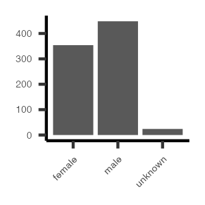

race

An arbitrary classification of a taxonomic group that is a division of a species. It usually arises as a consequence of geographical isolation within a species and is characterized by shared heredity, physical attributes and behavior, and in the case of humans, by common history, nationality, or geographic distribution. The provided values are based on the categories defined by the U.S. Office of Management and Business and used by the U.S. Census Bureau.

[figure not shown]

ethnicity

An individual's self-described social and cultural grouping, specifically whether an individual describes themselves as Hispanic or Latino. The provided values are based on the categories defined by the U.S. Office of Management and Business and used by the U.S. Census Bureau.

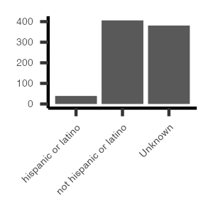

age_at_diagnosis

Age at the time of diagnosis expressed in number of days since birth.

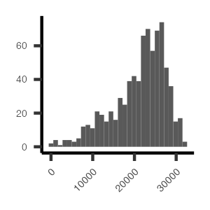

submitter_id

All submitted IDs can potentially contain identifiable information

[figure not shown]

**Intentionality of sensitive human attribute collection:** N/A

*LICENSING*

- **IP / Terms of Use:**
  - Raw data available from the [Genomic Data Commons](https://gdc.cancer.gov/about-gdc/gdc-policies) with access granted through [dbGaP](https://www.ncbi.nlm.nih.gov/projects/gap/cgi-bin/study.cgi?study_id=phs001657.v3.p1) and adherence to their [policies](https://dbgap.ncbi.nlm.nih.gov/aa/wga.cgi?view_pdf&stacc=phs001657.v3.p1)
- **Third party intellectual property considerations:**
  - N/A
- **Export controls or other regulations impacting dataset access/download or storage:**
  - N/A

Provenance and Lineage

**Description of the data collection methodology:** N/A

**Specific data collection devices:**

- N/A

**Dataset Curation:** N/A

**Dataset Validation:**

- N/A

**Data collection timeframe:** N/A

**Preprocessing steps/workflow:**

- **Pre-processing:** Generation and processing of raw data is described in detail in existing [publications](https://gdc.cancer.gov/content/beataml1.0-cohort-publication-summary)
- **Post-processing and derived features:** Generation of processed data by the Genomic Data Commons is described [here](https://gdc.cancer.gov/about-data/gdc-data-processing)